# chapter-8

Learning and Control Theories of Crime

## Learning Theories

Behavior is learned through interaction with others

When you hear “learning theories” think peers!

Critical Assumption:

People are assumed to start as “blank slates” (‘tabula rasa’) – no tendency toward or away from committing crime

Thus, criminal behavior is learned, NOT inherited.

## Differential Association Theory

Edwin Sutherland (1930s)

*“A person becomes delinquent because of an excess of definitions favorable to law violation over definitions unfavorable to law violation.”*

Learned primarily through interaction with close personal groups (e.g., peers)

Exposure to attitudes and values either favorable or unfavorable to law shapes an individual’s propensity to commit crime

The intensity, duration, frequency, and priority of these associations determine their influence

## Differential Reinforcement Theory

Robert Burgess & Ronald Akers

Individuals learn to either continue or discontinue behaviors based on the rewards or punishments they experience

Social environment provides definitions and reinforcements that can encourage or discourage criminal behavior (e.g., peer approval vs. disapproval)

Social environment adds positive or negative stimulus to criminal behavior

# Let’s See What AI Thinks This Looks Like 🤖

## Differential Reinforcement Theory 🤖 Image

1️⃣ A teen hangs out w/ group of peers who regularly shoplift

2️⃣ The first time the teen shoplifts, they feel nervous - but the group praises

That positive reinforcement (peer approval) increases the likelihood they’ll do it again

3️⃣ Later, the teen is caught by store security and receives a suspension from school, along with disappointment from their parents

4️⃣ This negative consequence (punishment) makes them reconsider the behavior

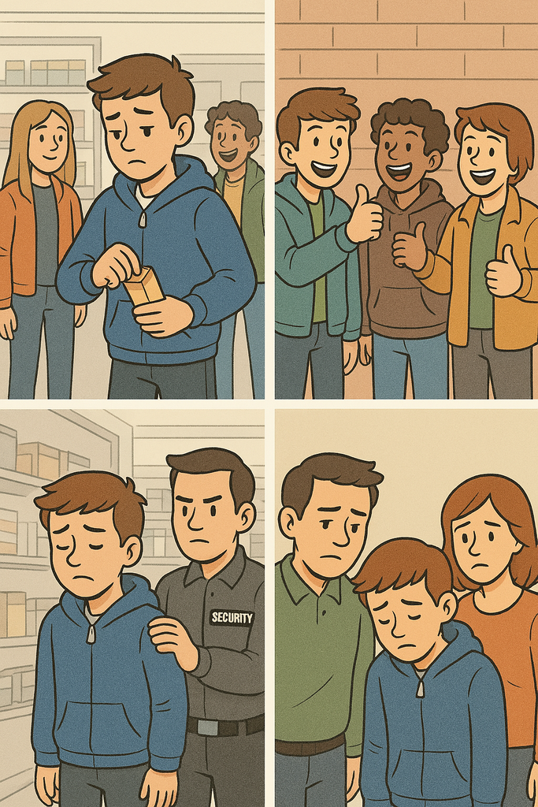

## Operant Conditioning

**B. F. Skinner**

Explains how behavior is shaped by consequences in the environment

Positive Reinforcement: Presenting a desirable stimulus after a behavior (increases likelihood of the behavior)

Negative Reinforcement: Removing an unpleasant stimulus when the behavior occurs (also increases likelihood of the behavior)

Punishment: Applying an unpleasant consequence or removing a pleasant one (decreases likelihood of the behavior)

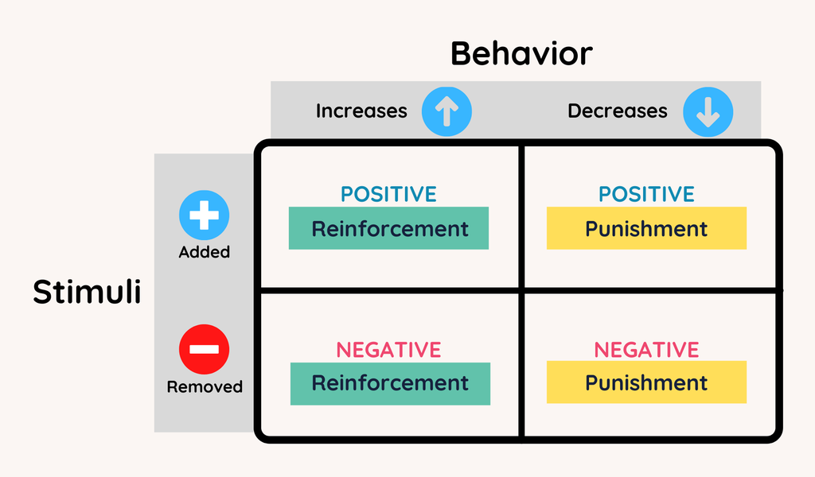

## Modeling and Imitation

Individuals learn not only from direct rewards/punishments but also from observing others’ behavior and its consequences

If a role model is seen being rewarded (or not punished) for criminal behavior, observers are more likely to imitate that behavior

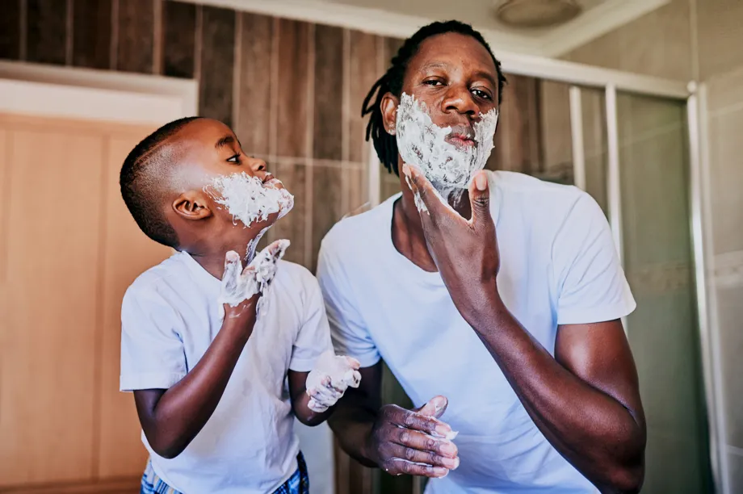

## Neutralization Theory

Gresham Sykes & David Matza (1957)

Core Idea: Delinquents often drift between conventional and deviant behaviors rather than being committed to criminality full-time

While they generally accept mainstream moral values, they use justifications or ‘techniques of neutralization’ to temporarily suspend or neutralize these values when engaging in delinquency

## Techniques of Neutralization

Denial of Responsibility

Diminishing personal accountability

Example: “It wasn’t my fault; I was just following orders.”

Denial of Injury

Offenders minimize or deny the harm, suggesting no real injury occurred

Example: “No one really got hurt,” or “They can afford the loss.”

Denial of the Victim

Victim deserved the harm or that there is no true victim

Example: “They had it coming.”

Condemnation of the Condemners

Shifts blame to those who disapprove of the act, accusing them of being hypocritical

Example: “You’ve done worse things yourself.”

Appeal to Higher Loyalties

Argues that their actions serve a greater good

Example: “I did it for my family/friends,” or “My loyalty to the group takes priority.”

# Group Discussion!!!!

## Group Discussion

`10:00`

If the instant gratification of likes on platforms like TikTok reinforces or normalizes deviant behaviors among viewers, what platform-level strategies or features could be introduced to discourage such conduct without significantly reducing user engagement?

For example, content warnings and rating labels were added to films in the 1970s to guide audiences, which parallels to this idea.

Pick one and make an argument for your choice. Elect one speaker to present your point.

# Control Theories

## Sigmond Freud

Austrian neurologist

Founder of psychoanalysis - a method for treating mental illness and understanding the human psyche

Proposed a tripartite model — id, ego, and superego

Emphasized the role of the unconscious shaping behavior

Believed dreams are expressions of unconscious wishes, detailed in *The Interpretation of Dreams (1900)*

Introduced defense mechanism concepts like repression, denial, and projection to explain ego protection

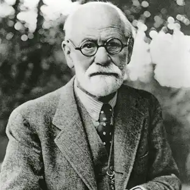

## Freud’s Tripartite Model

Ego - *Conscious*

Rational mediator between Id and Superego

Operates on the reality principle - evaluate the world and act accordingly by delaying gratification and considering consequences)

Assesses the external world and balances competing demands

Superego - *Pre-conscious*

Internalization of societal norms and moral standards

Strives for perfection

Generates feelings of guilt

Id - Unconscious

Innate and primitive

Driven by the pleasure principle (immediate gratification)

Highly impulsive

Present at birth

## Freud’s Iceberg Metaphor

“The mind is like an iceberg, it floats with one-seventh of its bulk above water.”

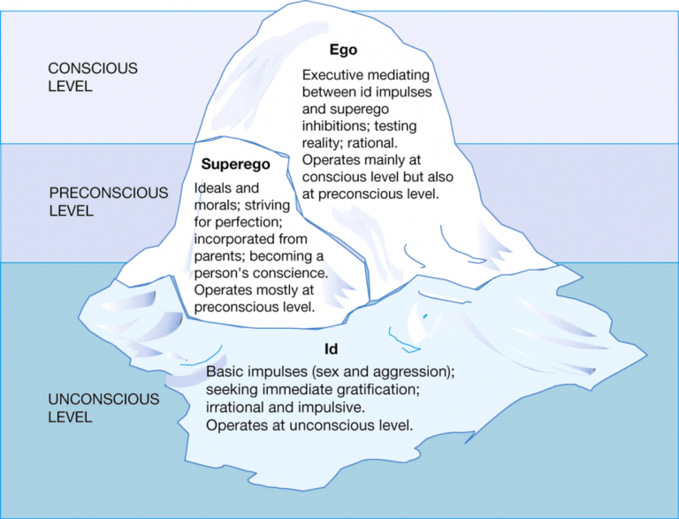

Image: Medium

## Freud’s Concepts

Many of Freud’s concepts have been rejected in modern psychology

And much of his work was untestable

Although his work was highly influential and influenced many criminological idea

## Connection to Control Theories

Internal Control Mechanism:

A strong superego (id becomes non-dominate) acts as an internal brake against deviance

A weak superego may lead to poor impulse control (id becomes dominate) which can which reduces adherence to social bonds and increase likelihood of deviance

Superego is Developed by Social Bonds:

Socialization (e.g., family, education) shapes the superego

## Toby’s Stake in Conformity

Jackson Toby

Stake in conformity

Refers to an individual’s personal investment (e.g., family, friends) in adhering to social norms and avoiding deviant behavior

The more an individual stands to lose by violating rules (reputation, job, relationships), the higher their stake in conformity

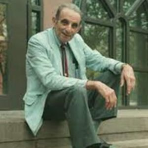

Image: Rutgers

## Reckless’s Control Theory

Explains why individuals resist criminal behavior

When inner and outer containment are strong, the resistance is strong

Inner Containment (Prevents Pushes)

Strong self-concept and sense of identity

Personal self-control, moral compass, and conscience

Outer Containment (Prevents Pulls)

Social structures (family, community, peer support)

Consistent enforcement of norms and rules

Pushes and Pulls Toward Deviance

Pushes: Internal drives or impulses (e.g., frustration, rebellion)

Pulls: External lures (e.g., gang influence, media glamorization of deviance)

## Hirschi’s Social Bonding Theory

Travis Hirschi (1969)

The stronger an individual’s attachment, commitment, involvement, and belief in societal norms, the less likely they are to engage in deviant or criminal behavior

Key Elements of the Social Bond

1️⃣ Attachment

Emotional closeness to significant others (family, friends), desire to maintain these bond

2️⃣ Commitment

Investment in conventional goals (education, career), fear of losing what’s been achieved

3️⃣ Involvement

Time spent in productive or prosocial activities, ‘Idle hands’ are minimized

4️⃣ Belief

Acceptance of societal rules and moral values, strong internalization of norms

## Low Self-Control

Gottfredson & Hirschi

Proposes that low self-control, in the presence of criminal opportunity, leads to deviant or criminal behavior

Two major Elements

Low Self-Control

Characterized by impulsivity, preference for simple tasks, risk-seeking, and insensitivity to others

Largely established early in childhood (through inadequate socialization)

Opportunity

Situations where rules can be violated with minimal risk

## Low Self-Control

Development of Low Self-Control

Socialization

Effective child-rearing and socialization can foster higher self-control

Inadequate parenting increases the likelihood of low self-control

Stability Over Time

Remains stable through life

# Group Discussion!!!!

## Group Discussion

`10:00`

After your experience with extended remote learning during COVID, were your peers (or yours) attachments to school values and community permanently changed? Consider the absence of in-person classes, casual hallway interactions, sports events, prom etc…

Did you notice any changes peer behavior that would align with Hirchi’s Social Bonding Theory?

Have these effects persisted into college or disappeared once traditional, face-to-face classes resume?

Make an argument for your choice. Elect one speaker to present your point.

## Have a Great Weekend!

[figure not shown]

Image: Giphy